# Palmetto binary logistic regression

## Overview:

In this report we explore, a dataset of palmetto species. The dataset was originally collected by the author Abrahamson, W.G. to investigate survival, growth and biomass estimates of two dominant palmetto species of south-central Florida from 1981 to 2017. Using a binary logistic regression to test feasibility of using different variables of plant height (height), canopy length (length), canopy width (width), and number of green leaves (green_lvs)(i.e.explanatory variables); and their relationship with the independent variable. We try to evaluate via two models whether these independent variables/ plant characteristics can help classify a correct palmetto specie (Serenoa repens or Sabal etonia).

**Data source**: Abrahamson, W.G. 2019. Survival, growth and biomass estimates of two dominant palmetto species of south-central Florida from 1981 - 2017, ongoing at 5-year intervals ver 1. Environmental Data Initiative. https://doi.org/10.6073/pasta/f2f96ec76fbbd4b9db431c79a770c4d5

```r
knitr::opts_chunk$set(echo = TRUE,message = FALSE,warning = FALSE)
library(tidyverse)
library(here)
library(GGally)
library(broom)
library(jtools)
library(caret)
library(AICcmodavg)
library(equatiomatic)
library(kableExtra)
library(kimisc)
library(sjPlot)
```

## Data wrangling

```r
# Convert species to a 'factor'
palmetto_clean <- read_csv(here('data','palmetto.csv'))  %>%
  rename(length_cm = length, height_cm= height, width_cm=width) %>%

  mutate(species = case_when(
                     species == 1 ~ "Serenoa repens",
                     species == 2 ~ "Sabal etonia",)) %>%
   mutate(species = as.factor(species))%>%
   # select(- comments, -year) %>%
  select(height_cm,length_cm,width_cm,green_lvs,species)  %>%
  drop_na()
```

## Data visualization

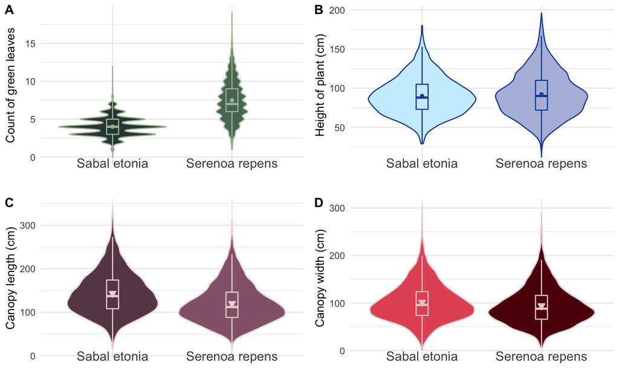

Figure 1: Exploratory graphs of palmetto species vs other independent variables

```r
p1 <-ggplot(data = palmetto_clean, aes(x = species, y = green_lvs, fill = species)) +
  geom_violin(scale = "count", color = "#abbe9e") + # mirrored density plot
  geom_boxplot(color = "#abbe9e", fill = NA, width = 0.1, outlier.color = NA) +
  stat_summary(fun=mean,
               geom="point",
               shape=20,
               size=2,
               color="#abbe9e",
               fill="#abbe9e") +
  scale_fill_manual(values = c("#304545", "#597567")) +
  theme_minimal(11) + # change theme and font size
  theme(legend.position = "none",
        axis.text.x = element_text(vjust = 5, size = 12)) +
  labs(x = element_blank(), y = "Count of green leaves")

p2 <-ggplot(data = palmetto_clean, aes(x = species, y = height_cm, fill = species)) +
  geom_violin(scale = "count", color = "#1a4da9") +
  geom_boxplot(color = "#1a4da9", fill = NA, width = 0.1, outlier.color = NA) +
  stat_summary(fun=mean,
               geom="point",
               shape=20,
               size=2,
               color="#1a4da9",
               fill="#1a4da9") +
  scale_fill_manual(values = c("#cceeff", "#b4bcdc")) +
  theme_minimal(11) +
  theme(legend.position = "none",
        axis.text.x = element_text(vjust = 5, size = 12)) +
  labs(x = element_blank(), y = "Height of plant (cm)")

p3 <-ggplot(data = palmetto_clean, aes(x = species, y = length_cm, fill = species)) +
  geom_violin(scale = "count", color = "#eed7da") +
  geom_boxplot(color = "#eed7da", fill = NA, width = 0.1, outlier.color = NA) +
  stat_summary(fun=mean,
               geom="point",
               shape=25,
               size=2,
               color="#eed7da",
               fill="#eed7da") +
  scale_fill_manual(values = c("#674655", "#94657a")) +
  theme_minimal(11) +
  theme(legend.position = "none",
        axis.text.x = element_text(vjust = 5, size = 12)) +
  labs(x = element_blank(), y = "Canopy length (cm)")

p4 <-ggplot(data = palmetto_clean, aes(x = species, y = width_cm, fill = species)) +
  geom_violin(scale = "count", color = "#e7d0d0") +
  geom_boxplot(color = "#e7d0d0", fill = NA, width = 0.1, outlier.color = NA) +
  stat_summary(fun=mean,
               geom="point",
               shape=25,
               size=2,
               color="#e7d0d0",
               fill="#e7d0d0") +
  scale_fill_manual(values = c("#e55763", "#5d040b")) +
  theme_minimal(11) +
  theme(legend.position = "none",
        axis.text.x = element_text(vjust = 5, size = 12)) +
  labs(x = element_blank(), y = "Canopy width (cm)")



cowplot::plot_grid(
          p1, p2, p3, p4,
          nrow = 2,
          labels = c('A', 'B', 'C', 'D'),
          label_size = 12,

          align="hv")
```

- Plot (A): Sabal etonial has on average lower green leaves count compared to Serenoa repens.
- Plot(B): Both palmetto plant species seem to have similar plant heights.
- Plot(C): Sabal etonia seems to have a slight longer canopy compared to Serenoa repens.
- Plot(D): In terms of canopy width, both plant species have almost comparable canopy width.

## Data analysis

#### Binary logistic regression

In this section, we explore the probability of a plant being either “Serenoa repens” or Sabal etonia” based on predictor variables. We perform the analysis twice, using cross validation to compare two models:

- 1. Log odds of plant type using plant height, canopy length, canopy width and green leaves as predictor variable.
- 2. Log odds of plant type using plant height, canopy width and green leaves (i.e., drop canopy length for this model)

```r
# start by defining
f1 <- species ~ height_cm + length_cm + width_cm + green_lvs
f2 <- species~ height_cm +  width_cm + green_lvs

palmetto_blr1 <- glm(formula = f1,
                    data = palmetto_clean,
                    family = "binomial")

# palmetto_blr1
# summary(palmetto_blr1)

palmetto_blr2 <- glm(formula = f2,
                    data = palmetto_clean,
                    family = "binomial")

# palmetto_blr2
# summary(palmetto_blr2)
```

#### Model selection

Let’s compare the models using AICc

```r
# AICcmodavg::aictab(list(palmetto_blr1, palmetto_blr2))
model_list <- nlist(palmetto_blr1, palmetto_blr2)
aic_table <- aictab(model_list)
aic_table_stats <-  aic_table %>%
  kable(caption="Table 1.Summary statistics of AIC values from Model 1 & Model 2 ") %>%
  kable_styling(
                bootstrap_options = c("striped","hover","bordered","italic"), full_width = TRUE,position = "left", html_font="Cambria", font_size = 14) %>%
  add_footnote(c("Data source:Abrahamson, W.G. 2019. Survival, growth and biomass estimates of two
dominant palmetto species of south-central Florida from 1981 - 2017."), notation = "symbol") %>%
  remove_column(1)

aic_table_stats
```

Table 1.Summary statistics of AIC values from Model 1 & Model 2

| K | AICc | Delta_AICc | ModelLik | AICcWt | LL | Cum.Wt |
| --- | --- | --- | --- | --- | --- | --- |
| 5 | 5194.567 | 0.0000 | 1 | 1 | -2592.281 | 1 |
| 4 | 5987.475 | 792.9086 | 0 | 0 | -2989.736 | 1 |

* Data source:Abrahamson, W.G. 2019. Survival, growth and biomass estimates of two dominant palmetto species of south-central Florida from 1981 - 2017.

From table 1, we can see that the value of AICc from model 1 is lower with a value of 5194.57 and the AICc from model 2 is higher with a value of 5987.48.

```r
set.seed(123)
# tr_ctrl <- trainControl(method = "cv", number = 10)
tr_ctrl <- trainControl(method = "repeatedcv", number = 10, repeats = 10)

# Train the model
model1 <- train(f1, data = palmetto_clean,
               method = "glm", family = 'binomial',
               trControl = tr_ctrl)
# model1

model2 <- train(f2, data = palmetto_clean,
               method = "glm", family = 'binomial',
               trControl = tr_ctrl)
# model2
```

```r
final_mdl <- glm(formula = f1,
                    data = palmetto_clean,
                    family = "binomial")

broom::tidy(final_mdl) %>%
   mutate(p.value = case_when( # rename p-values for readability
    p.value <0.001 ~ "<0.001"
  )) %>%
  mutate(estimate = round(estimate,3),std.error = round(std.error,3)) %>%
  mutate(term = case_when(
         term == "(Intercept)" ~ "Intercept",
         term == "height_cm" ~ "Height (cm)",
         term == "length_cm" ~ "Length (cm)",
         term == "width_cm" ~ "Width (cm)",
         term == "green_lvs" ~ "Green leaves count")) %>%
  select(-statistic) %>%
  rename( " " = term, "Coefficient" = estimate, "Standard error" = std.error, "P-Value"=p.value
) %>%

  kable(align="lccc",caption="Table 2.Summary statistics of Model 1") %>%
  kable_styling(
                bootstrap_options = c("striped","hover","bordered","italic"), full_width = TRUE,position = "left", html_font="Cambria", font_size = 14) %>%
  add_footnote(c("Data source:Abrahamson, W.G. 2019. Survival, growth and biomass estimates of two
dominant palmetto species of south-central Florida from 1981 - 2017."), notation = "symbol")
```

Table 2.Summary statistics of Model 1

|  | Coefficient | Standard error | P-Value |
| --- | --- | --- | --- |
| Intercept | -3.227 | 0.142 | <0.001 |
| Height (cm) | 0.029 | 0.002 | <0.001 |
| Length (cm) | -0.046 | 0.002 | <0.001 |
| Width (cm) | -0.039 | 0.002 | <0.001 |
| Green leaves count | 1.908 | 0.039 | <0.001 |

* Data source:Abrahamson, W.G. 2019. Survival, growth and biomass estimates of two dominant palmetto species of south-central Florida from 1981 - 2017.

**Our final model**:
$$\begin{aligned}
\log\left[ \frac { P( \operatorname{species} = \operatorname{Serenoa\
repens} ) }{ 1 - P( \operatorname{species} = \operatorname{Serenoa\
repens} ) } \right] &= \alpha + \beta_{1}(\operatorname{height\_cm})
+ \beta_{2}(\operatorname{length\_cm}) +
\beta_{3}(\operatorname{width\_cm})\ + \\
&\quad \beta_{4}(\operatorname{green\_lvs})
\end{aligned}$$

and with coefficients in place:
$$\begin{aligned}
\log\left[ \frac { \widehat{P( \operatorname{species} =
\operatorname{Serenoa\ repens} )} }{ 1 - \widehat{P(
\operatorname{species} = \operatorname{Serenoa\ repens} )} } \right]
&= -3.23 + 0.03(\operatorname{height\_cm}) -
0.05(\operatorname{length\_cm}) - 0.04(\operatorname{width\_cm})\ + \\
&\quad 1.91(\operatorname{green\_lvs})
\end{aligned}$$

```r
# make predictions

predict_acc <- function(x, y) {
  accurate <- ifelse(x == y, 1, 0)
  return(accurate)
}


blr1_fitted <- palmetto_blr1 %>%
  broom::augment(type.predict = "response") %>%
    mutate(predicted_species = case_when(
    .fitted >= 0.5 ~ "Serenoa repens",
    .fitted < 0.5 ~ "Sabal etonia"
  )) %>%
  mutate(prediction_result = predict_acc(species, predicted_species))


blr2_fitted <- palmetto_blr2 %>%
  broom::augment(type.predict = "response") %>%
    mutate(predicted_species = case_when(
    .fitted >= 0.5 ~ "Serenoa repens",
    .fitted < 0.5 ~ "Sabal etonia"
  )) %>%
  mutate(prediction_result = predict_acc(species, predicted_species))


# See what percentage of the time the model predicted correctly
blr1_acc <- blr1_fitted  %>%
  group_by(species) %>%
  summarize(pred_accuracy_v = round(mean(prediction_result), 2)) %>%
  kable(align = "ll",
      col.names = c("Species", "% correctly classified"),caption="Table 3. Model 1 probability of correctly classifying palmetto species") %>% kable_styling(
                bootstrap_options = c("striped","hover","bordered","italic"), full_width = TRUE,position = "left", html_font="Cambria", font_size = 14) %>%
  add_footnote(c("Data source:Abrahamson, W.G. 2019. Survival, growth and biomass estimates of two
dominant palmetto species of south-central Florida from 1981 - 2017."), notation = "symbol")

blr2_acc <- blr2_fitted  %>%
  group_by(species) %>%
  summarize(pred_accuracy_v = round(mean(prediction_result), 2)) %>%
  kable(align = "ll",
      col.names = c("Species", "% correctly classified"),caption="Table 4. Model 2 probability of correctly classifying palmetto species") %>% kable_styling(
                bootstrap_options = c("striped","hover","bordered","italic"), full_width = TRUE,position = "left", html_font="Cambria", font_size = 14) %>%
  add_footnote(c("Data source:Abrahamson, W.G. 2019. Survival, growth and biomass estimates of two
dominant palmetto species of south-central Florida from 1981 - 2017."), notation = "symbol")

blr1_acc
```

Table 3. Model 1 probability of correctly classifying palmetto species

| Species | % correctly classified |
| --- | --- |
| Sabal etonia | 0.93 |
| Serenoa repens | 0.91 |

* Data source:Abrahamson, W.G. 2019. Survival, growth and biomass estimates of two dominant palmetto species of south-central Florida from 1981 - 2017.

```r
blr2_acc
```

Table 4. Model 2 probability of correctly classifying palmetto species

| Species | % correctly classified |
| --- | --- |
| Sabal etonia | 0.91 |
| Serenoa repens | 0.89 |

* Data source:Abrahamson, W.G. 2019. Survival, growth and biomass estimates of two dominant palmetto species of south-central Florida from 1981 - 2017.